# Portfolio assignment 7

15 min: Look at the histogram of at least 2 columns with numerical data in the dataset that you chose in portfolio assignment 4. Do you recognise the distribution? Does it look like a uniform or normal distribution or something else? If it doesn't look like a uniform or normal distribution, take a quick look here to see if you can find the distribution shape: https://www.itl.nist.gov/div898/handbook/eda/section3/eda366.htm

```python
import pandas as pd

movies = pd.read_csv (r'movies.csv')
```

### Runtime

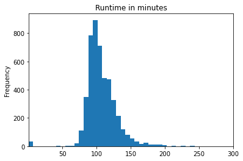

```python
movies['runtime'].plot(kind='hist', bins = 50, xlim=(1,300), title= "Runtime in minutes")
```

De runtime lijkt een lognormal distributie te hebben met enkele outliers te hebben aan de linkerkant.

### Vote Average

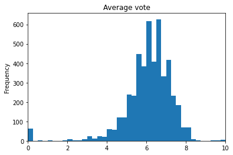

```python
movies['vote_average'].plot(kind='hist', bins = 40, xlim=(0,10), title= "Average vote")
```

### Budget

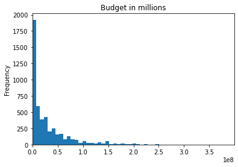

```python
movies['budget'].plot(kind='hist', bins =50, xlim=(0), title= "Budget in millions")
```

De budgets van alle films heeft een exponentiele distributie.

# Portfolio assignment 8

15 min:

- Calculate the 90%, 95%, 99% and 99.99% confidence interval for at least 2 columns with numerical data in the dataset that you chose in portfolio assignment 4. Do you see the impact the confidence has on the interval?
- Now calculate the 95% confidence interval again but use only the first 10% of your rows. Compare this interval to the previous 95% confidence interval you calculated. Do you see the impact of having less data?

```python
import scipy.stats as st
```

```python
n = 10
```

### Vote Average

90%

```python
confidence = 0.90
st.t.interval(confidence, len(movies)-1, loc=movies['vote_average'].mean(), scale=st.sem(movies['vote_average']))
```

```
(6.063813161893738, 6.120529956990285)
```

95%

```python
confidence = 0.95
st.t.interval(confidence, len(movies)-1, loc=movies['vote_average'].mean(), scale=st.sem(movies['vote_average']))
```

```
(6.058378445785645, 6.125964673098378)
```

99%

```python
confidence = 0.99
st.t.interval(confidence, len(movies)-1, loc=movies['vote_average'].mean(), scale=st.sem(movies['vote_average']))
```

```
(6.047753418852622, 6.136589700031401)
```

99.99%

```python
confidence = 0.9999
st.t.interval(confidence, len(movies)-1, loc=movies['vote_average'].mean(), scale=st.sem(movies['vote_average']))
```

```
(6.025051661499075, 6.159291457384948)
```

95% with only the first 10% of the rows

```python
confidence = 0.95
st.t.interval(confidence, len(movies)-1, loc=movies['vote_average'].head(int(len(movies)*(n/100))).mean(), scale=st.sem(movies['vote_average'].head(int(len(movies)*(n/100)))))
```

```
(6.271038383161902, 6.411461616838097)
```

### Budget

90%

```python
confidence = 0.90
st.t.interval(confidence, len(movies)-1, loc=movies['budget'].mean(), scale=st.sem(movies['budget']))
```

```
(28078348.093349915, 30011731.657222643)
```

95%

```python
confidence = 0.95
st.t.interval(confidence, len(movies)-1, loc=movies['budget'].mean(), scale=st.sem(movies['budget']))
```

```
(27893087.435024343, 30196992.31554822)
```

99%

```python
confidence = 0.99
st.t.interval(confidence, len(movies)-1, loc=movies['budget'].mean(), scale=st.sem(movies['budget']))
```

```
(27530897.49810984, 30559182.252462722)
```

99.99%

```python
confidence = 0.9999
st.t.interval(confidence, len(movies)-1, loc=movies['budget'].mean(), scale=st.sem(movies['budget']))
```

```
(26757031.406704944, 31333048.34386762)
```

95% with only the first 10% of the rows

```python
confidence = 0.95
st.t.interval(confidence, len(movies)-1, loc=movies['budget'].head(int(len(movies)*(n/100))).mean(), scale=st.sem(movies['budget'].head(int(len(movies)*(n/100)))))
```

```
(119103833.59093952, 128172209.75489381)
```

Hoe minder data, hoe groter het interval level (meer deviatie)